# Kmeans Implementation

Dan Shabo

4/10/2022

```r
library(dplyr)
library(tidyverse)
library(tidyr)
library(readr)
library(ggplot2)
library(plotly)
library(dendextend)
euclidean <- function(a, b) sqrt(sum((a - b)^2))
```

Each value in the dataset med_dat measures the median expression level of the gene across multiple samples of the same tissue.

```r
med_dat = read.delim("gtex.txt",skip = 2 , row.names=c(1) , header = TRUE)
gen_names =med_dat[ ,1]
med_dat = med_dat[ ,-1]

# Transpose the data:
med_dat = t(med_dat)

#Cleaning genes with 0 expression in any tissue:
med_dat <- med_dat[,which((apply(med_dat,2, sum) != 0) == 1)]

#Using the log(x+1) transformation to stabilize the distances.
med_dat = log(med_dat + 1)

#Reducing the data table to the 200 genes with the maximal variance across examples.
med_dat <- rbind(med_dat,apply(med_dat,2,sd))
sd_vector <- med_dat[54,]
med_dat <- med_dat[,order(med_dat[54,],decreasing = TRUE)]
med_dat = med_dat[1:53,1:200]
```

I did that so we can sample from different quadrants and we won’t get close centers for the kmeans later. This is the function that creates the fake quadrants for data $\in \mathbb{R}^2$, the function returns each quadrant along with the data points it contains.

```r
get.quadrants<- function(dataset)
{
  x_range <- c(min(main_pcs[,1]),max(main_pcs[,1]))
  y_range <- c(min(main_pcs[,2]),max(main_pcs[,2]))

  quadrant1_range <-  list(x_range = c(x_range[1],median(x_range)),y_range = c(median(y_range),y_range[2]))
  quadrant1_val <- main_pcs[which((quadrant1_range$x_range[1] <= main_pcs[,1] &  main_pcs[,1] <= quadrant1_range$x_range[2]) & (quadrant1_range$y_range[1] <= main_pcs[,2] &  main_pcs[,2] <= quadrant1_range$y_range[2])),]

  quadrant2_range <-  list(x_range = c(median(x_range),x_range[2]),y_range = c(median(y_range),y_range[2]))
  quadrant2_val <- main_pcs[which((quadrant2_range$x_range[1] <= main_pcs[,1] &  main_pcs[,1] <= quadrant2_range$x_range[2]) & (quadrant2_range$y_range[1] <= main_pcs[,2] &  main_pcs[,2] <= quadrant2_range$y_range[2])),]

  quadrant3_range <-  list(x_range = c(x_range[1],median(x_range)),y_range = c(y_range[1],median(y_range)))
  quadrant3_val <- main_pcs[which((quadrant3_range$x_range[1] <= main_pcs[,1] &  main_pcs[,1] <= quadrant3_range$x_range[2]) & (quadrant3_range$y_range[1] <= main_pcs[,2] &  main_pcs[,2] <= quadrant3_range$y_range[2])),]

  quadrant4_range <-  list(x_range = c(median(x_range),x_range[2]),y_range = c(y_range[1],median(y_range)))
  quadrant4_val <- main_pcs[which((quadrant4_range$x_range[1] <= main_pcs[,1] &  main_pcs[,1] <= quadrant4_range$x_range[2]) & (quadrant4_range$y_range[1] <= main_pcs[,2] &  main_pcs[,2] <= quadrant4_range$y_range[2])),]


  quadrants = list (q1 = quadrant1_val,q2 =quadrant2_val,q3 =quadrant3_val,q4 =quadrant4_val,axis_range =list(
             First =c("X Range:" = quadrant1_range$x_range,"Y Range:" = quadrant1_range$y_range),
             Second = c("X Range:" = quadrant2_range$x_range,"Y Range:" =quadrant2_range$y_range),
             Third = c("X Range:" = quadrant3_range$x_range,"Y Range:" =quadrant3_range$y_range),
             Fourth =c("X Range:" = quadrant4_range$x_range,"Y Range:" =quadrant4_range$y_range)))
  return(quadrants)
}
```

Now I’m going to reduce the dimension of the dataset by using PCA and get its quadrants using the function above:

```r
med_dat.pca <- prcomp(med_dat)
main_pcs <- med_dat.pca$rotation[,1:2]
example <- get.quadrants(main_pcs)
print(example$axis_range)
```

```
## $First
##    X Range:1    X Range:2    Y Range:1    Y Range:2
## -0.095617534  0.024429600  0.004276571  0.167285465
##
## $Second
##   X Range:1   X Range:2   Y Range:1   Y Range:2
## 0.024429600 0.144476735 0.004276571 0.167285465
##
## $Third
##    X Range:1    X Range:2    Y Range:1    Y Range:2
## -0.095617534  0.024429600 -0.158732324  0.004276571
##
## $Fourth
##    X Range:1    X Range:2    Y Range:1    Y Range:2
##  0.024429600  0.144476735 -0.158732324  0.004276571
```

Having the principal components divided by median helps us sampling centers that are not relatively close. Now I can set my sampling order, each quadrant at a time.

The following function takes a $\ k$ values (the number of clusters), a data-set, and the maximal iterations, and returns the centers, the assignment, and the within-score.

```r
kmeans_m <- function(k,dataset,iter = 100){

  distances = data.frame()
  quadrants <- get.quadrants(dataset)
  quadrants_sample_order = rep((1:4),k)[1:k]
  centroids <- c()

  #Main Loop which is determined by input iterations:
  for (t in seq(iter)){
  #Loop for sampling the initial centroids, happens only in the first iteration:
  if (t == 1){
  for (i in quadrants_sample_order){
  centroids <- rbind(centroids, quadrants[[i]][sample(nrow(quadrants[[i]]),1),])}
  }
  #Computing euclidean distance between each observation and each centroid:
  for (i in seq(nrow(centroids))){
    for (j in seq(nrow(dataset))){
    distances[j,i] <- euclidean(dataset[j,],centroids[i,])}
  }
  }

  # Assignment for each observation:
  distances["assignment"] <-  apply(distances[1:k], 1, which.min)
  dataset_assign <- cbind(dataset,assignment = distances$assignment)

  #Creating new centroids based on the assignment's mean aggregation:
  centroids <- aggregate(cbind(dataset_assign[,1],dataset_assign[,2]) ~ assignment, data = dataset_assign, FUN = mean, na.rm = TRUE)[,2:3]

  #Computing within-score:
  min_dist <- cbind(distance =apply(distances[1:k], 1, min), assign = distances["assignment"])
  withinss <- aggregate(distance  ~ assignment, data = min_dist, FUN = sum, na.rm = TRUE)

  #Total withins:
  tot.withinss <- sum(withinss$distance)

  #Plot:
  plot(x =dataset[,1],y =dataset[,2], col = dataset_assign[,3],pch=16 ,xlab="PC1", ylab="PC2")
  points(centroids, col ='black' , pch=3,size = 5,cex = 2)
  return(list(centers = centroids,assignment = min_dist$assignment, withinss =withinss))
}
```

Function plot demonstration for 100 iterations :

```r
ex3_2 <- kmeans_m(4,main_pcs)
```

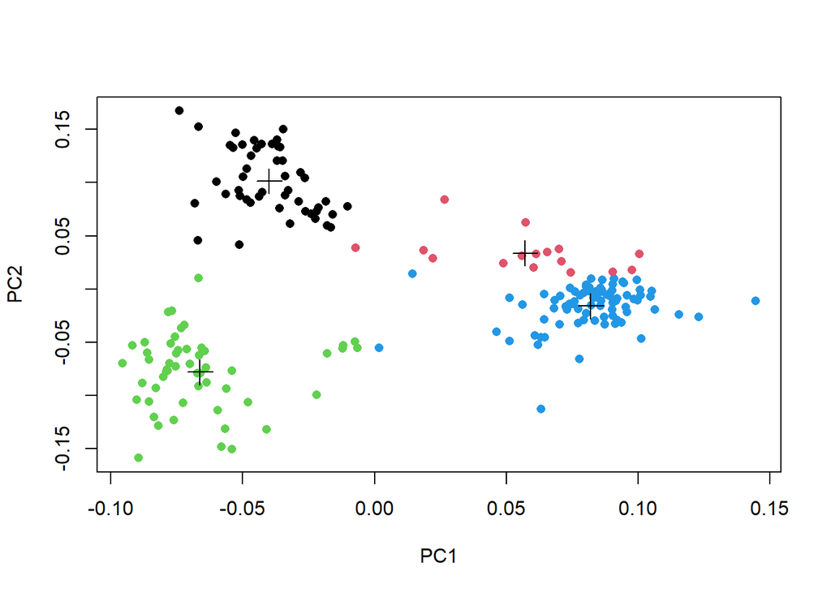

Final Centers:

```r
knitr::kable(ex3_2$centers)
```

| V1 | V2 |
| --- | --- |
| -0.0399748 | 0.1013282 |
| 0.0570345 | 0.0336485 |
| -0.0661884 | -0.0781145 |
| 0.0820016 | -0.0159631 |

```r
knitr::kable(head(ex3_2$assignment))
```

| x |
| --- |
| 4 |
| 3 |
| 4 |
| 3 |
| 3 |
| 4 |

Within score:

```r
knitr::kable(ex3_2$withinss)
```

| assignment | distance |
| --- | --- |
| 1 | 1.6622559 |
| 2 | 0.4714775 |
| 3 | 2.4610011 |
| 4 | 2.5013038 |